# Regressão Linear para Explicar a votação de Deputados

Luiz Fernando da Silva

26 de setembro de 2018

# Descrição dos Dados

Os dados podem ser baixados nos links a seguir: [Eleições 2006](https://canvas.instructure.com/courses/1402758/files/69433650/download?verifier=GvsTSXgoNVf22qbJerOSPAkHsOsdBUZD1Z1AD4lI), [Eleições 2010](https://canvas.instructure.com/courses/1402758/files/69433651/download?verifier=ZETCucixF9Mkjhfp7CLuchjRXWlSwtw69ZhQ0jyk), [Eleições 2006 + 2010](https://canvas.instructure.com/courses/1402758/files/69406530/download?verifier=w88G2kvz56ZJbCSGXgm22zKizUdptatpCDigS9ei&wrap=1).

“sequencial_candidato” :(character) id do candidato

“nome”: (character)

“uf”: (character)

“partido”: (character)

“quantidade_doacoes”: (integer)

“quantidade_doadores”: (integer) número de doadores diferentes

“total_receita”: (double) soma em R$ das doações

“media_receita”: (double) média das doações

“recursos_de_outros_candidatos/comites”: (double) quantia em R$ das doações provenientes de outros candidatos ou comite partidário

“recursos_de_pessoas_fisicas”: (double) quantia em R$ das doações provenientes de outros CPFs

“recursos_de_pessoas_juridicas”: (double) quantia em R$ das doações provenientes de outros CNPJ

“recursos_proprios”: (double) quantia em R$ das doações provenientes do próprio candidato

“recursos_de_partido_politico”: (double) quantia em R$ das doações provenientes do partido político do candidato

“votos”: (integer) variável alvo. Se refere ao número de votos na campanha de 2006 e 2010

“quantidade_despesas”: (integer)

“quantidade_fornecedores”: (integer) número de fornecedores/despesas diferentes

“total_despesa”: (double) soma em R$ das despesas de campanha

“media_despesa”: (double) média das despesas de campanha

“cargo”: (character)

“Sexo”: (character)

“grau”: (character) grau de instrução do candidato

“estado_civil”: (character)

“ocupacao”: (character) ocupação do candidato

#### Carregando os dados referentes as eleições de 2006, 2010 e 2006_2010

#### Preenchendo valores nulos com 0

```r
dados_2006_2010[is.na(dados_2006_2010)] = 0
dados_2006[is.na(dados_2006)] = 0
dados_2010[is.na(dados_2010)] = 0
```

#### Transformando variáveis categóricas

```r
dados_2006 %>%
  mutate(uf = as.factor(uf),
         nome = as.factor(nome),
         sexo = as.factor(sexo),
         grau = as.factor(grau),
         nome = as.factor(nome),
         cargo = as.factor(cargo),
         partido = as.factor(partido),
         ocupacao = as.factor(ocupacao),
         estado_civil = as.factor(estado_civil),
         sequencial_candidato = as.numeric(sequencial_candidato)) -> dados_2006
```

```r
dados_2010 %>%
  mutate(uf = as.factor(uf),
         nome = as.factor(nome),
         sexo = as.factor(sexo),
         grau = as.factor(grau),
         nome = as.factor(nome),
         cargo = as.factor(cargo),
         partido = as.factor(partido),
         ocupacao = as.factor(ocupacao),
         estado_civil = as.factor(estado_civil),
         sequencial_candidato = as.numeric(sequencial_candidato)) -> dados_2010
```

```r
dados_2006_2010 %>%
  mutate(uf = as.factor(uf),
         nome = as.factor(nome),
         sexo = as.factor(sexo),
         grau = as.factor(grau),
         nome = as.factor(nome),
         cargo = as.factor(cargo),
         partido = as.factor(partido),
         ocupacao = as.factor(ocupacao),
         estado_civil = as.factor(estado_civil),
         sequencial_candidato = as.numeric(sequencial_candidato)) -> dados_2006_2010
```

#### Filtrando variáveis categóricas que não possuem mais de uma categoria, ou cada linha é uma categoria diferente, o que não ajuda na construção dos modelos.

```r
dados_filtrados_2006 <- dados_2006 %>% select(-nome, -ano, -cargo)
```

```r
dados_filtrados_2010 <- dados_2010 %>% select(-nome, -ano, -cargo)
```

```r
dados_filtrados_2006_2010 <- dados_2006_2010 %>% select(-nome, -ano, -cargo)
```

### Questão 1 - Um modelo de regressão múltipla com todas as variáveis é plausível para explicar a variação em y (número de votos) em 2006? Mesma pergunta para 2010.

Um modelo de regressão linear multipla com todas as variáveis não é tão bom para explicar a variação de y (Quantidade de votos), pois analizando as regressões criadas com os dados de 2006 e 2010, podemos observar que o R² não é tão alto (0.57 nos dados de 2006 e 0.54 nos de 2010) o que mostra que usar todas as variáveis não é bom para explicar os voto. Pode-se obsevar também que a muitas variáveis que não são necessárias no modelo, tais como, quantidade_despesas, quantidade_fornecedores e recursos_de_partido_politico.

```r
lmModel2006 <- dados_filtrados_2006 %>% lm(formula=votos ~ .)
broom::glance(lmModel2006)
```

```
## # A tibble: 1 x 11
##   r.squared adj.r.squared  sigma statistic p.value    df  logLik    AIC
## *     <dbl>         <dbl>  <dbl>     <dbl>   <dbl> <int>   <dbl>  <dbl>
## 1     0.578         0.549 30549.      19.8       0   223 -40244. 80936.
## # ... with 3 more variables: BIC <dbl>, deviance <dbl>, df.residual <int>
```

```r
lmModel2010 <- dados_filtrados_2010 %>% lm(formula = votos ~ .)
broom::glance(lmModel2010)
```

```
## # A tibble: 1 x 11
##   r.squared adj.r.squared  sigma statistic p.value    df  logLik    AIC
## *     <dbl>         <dbl>  <dbl>     <dbl>   <dbl> <int>   <dbl>  <dbl>
## 1     0.541         0.513 34587.      19.6       0   230 -47837. 96136.
## # ... with 3 more variables: BIC <dbl>, deviance <dbl>, df.residual <int>
```

### 2- Compare as regressões construídas para 2006 e 2010. Quais as diferenças/semelhanças percebidas? Algumas sugestões: Analise os plots de resíduos e verifique se há tendências nos erros para cada ano.

- Analise os plots de resíduos e verifique se há tendências nos erros para cada ano.
- Quais variáveis conseguem explicar melhor o número de votos? Compare essas variáveis entre os modelos. Mesma coisa para as variáveis menos explicativas.
- Compare os valores de R2 e RSE considerando as regressões para cada ano.
- Inclua outros pontos de comparação que você ache interessante.

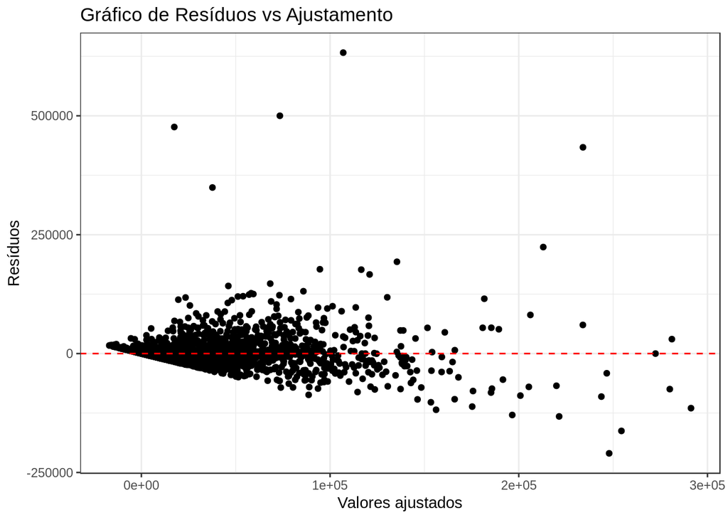

```r
p1 = ggplot(lmModel2006, aes(.fitted, .resid)) +
    geom_point()
p1 = p1 + geom_hline(yintercept=0, col="red", linetype="dashed")
p1 = p1 + xlab("Valores ajustados") + ylab("Resíduos")
p1 = p1 + ggtitle("Gráfico de Resíduos vs Ajustamento") +
    theme_bw()
p1
```

Como podemos visualizar no plot de resíduos acima os erros não parecem estar distruibuidos de forma aleatória e simétrica em torno da linha potilhada, o indica que o modelo não conseguiu explicar bem os erros nos dados, Existem pontos onde eles estão mais juntos e outros onde estão bem dispersos. Além disso parece haver um padrão na distribuição dos erros, os resíduos tendem à assumir valores menores a medida que os valores ajustados aumentam.

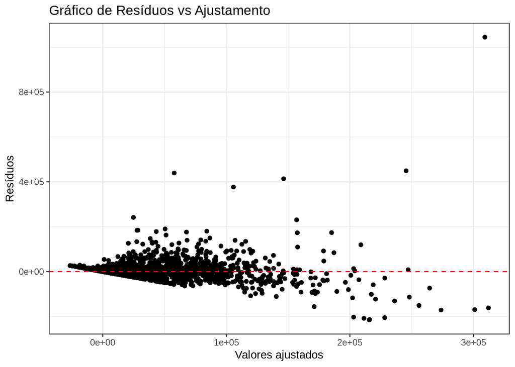

```r
p1 = ggplot(lmModel2010, aes(.fitted, .resid)) +
    geom_point()
p1 = p1 + geom_hline(yintercept=0, col="red", linetype="dashed")
p1 = p1 + xlab("Valores ajustados") + ylab("Resíduos")
p1 = p1 + ggtitle("Gráfico de Resíduos vs Ajustamento") +
    theme_bw()
p1
```

De forma semelhante ao plot dos dados de 2006, esse também não esté aleatoriamente e simetricamente distribuito em torno da linha pontilhada, o que indica que o modelo não explica bem os erros nos dados.

#### Comparando R² e RSE

[output not shown]

Analisando a tabela acima, percebe-se que o valor do R² é maior no modelo de 2006 e o RSE é menor também em 2006, o que indica que o modelo de relação linear escolhido se ajusta melhor aos dados de 2006.

#### Q-Q (Quantile-Quantile)

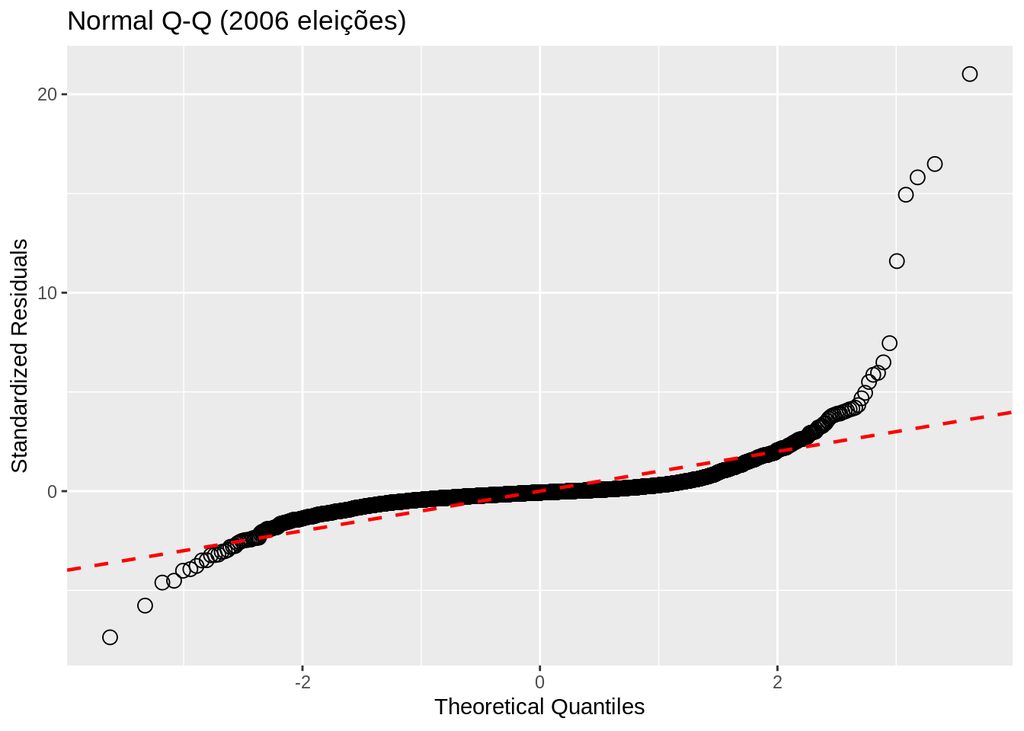

```r
lmModel2006 %>%
  ggplot(aes(sample=rstandard(.))) +
  stat_qq(na.rm = TRUE,
          shape=1,size=3) +
  labs(title="Normal Q-Q (2006 eleições)",        # plot title
  x="Theoretical Quantiles",      # x-axis label
  y="Standardized Residuals") +   # y-axis label +
  geom_abline(color = "red",
              size = 0.8,
              linetype="dashed")  # dashed reference line
```

Olhando para o gráfico acima pode-se observar que os resíduos estão próximos da reta porém possuem um leve desvío, o que indica que não são normalmente distríbuidos.

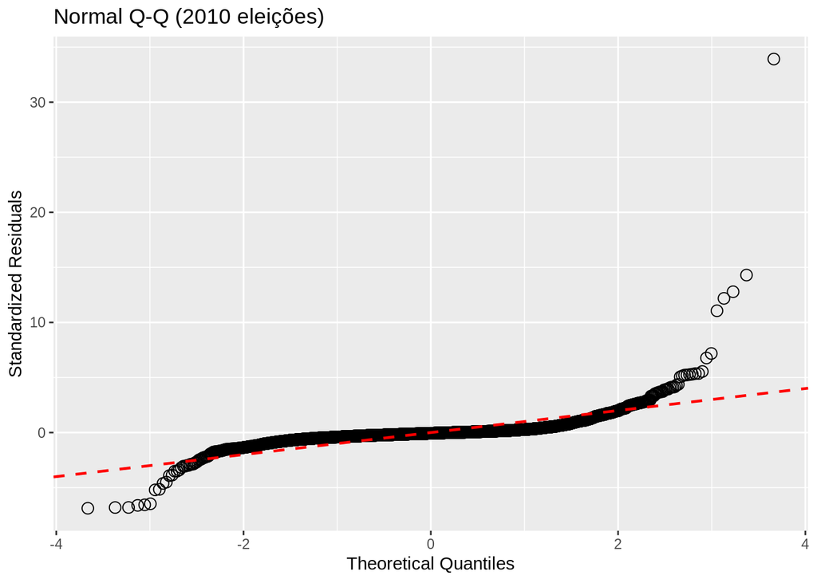

```r
lmModel2010 %>%
  ggplot(aes(sample=rstandard(.))) +
  stat_qq(na.rm = TRUE,
          shape=1,size=3) +
  labs(title="Normal Q-Q (2010 eleições)",        # plot title
  x="Theoretical Quantiles",      # x-axis label
  y="Standardized Residuals") +   # y-axis label +
  geom_abline(color = "red",
              size = 0.8,
              linetype="dashed")  # dashed reference line
```

### 3- Todas as variáveis são úteis para os modelos de regressão? Há variáveis redudantes? Faça análises para 2006 e 2010 separadamente.

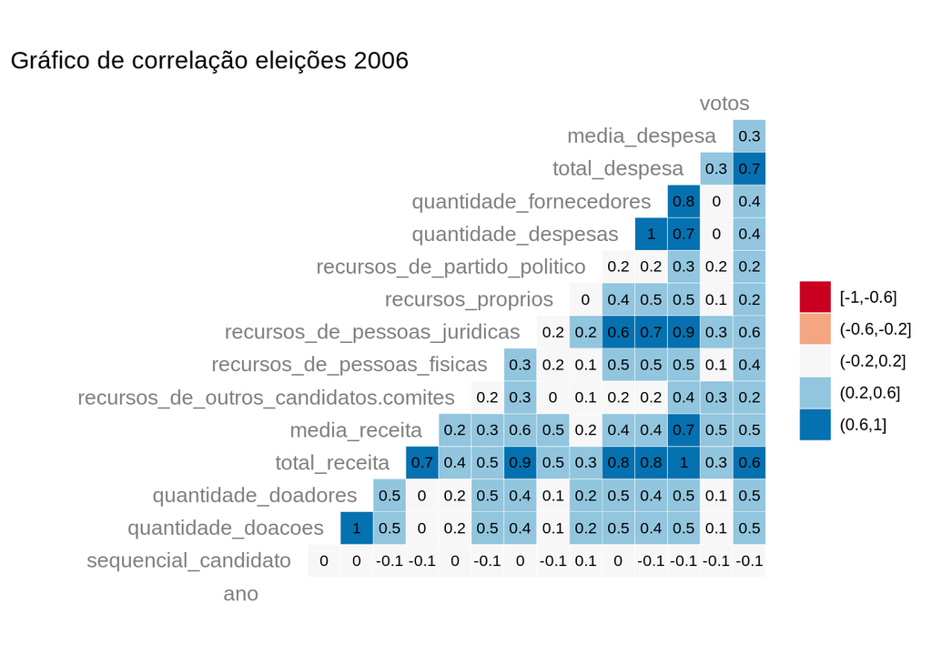

```r
dados_2006 %>%
  na.omit() %>%
  ggcorr(palette = "RdBu",
         color = "grey50",
         label = TRUE, hjust = 1,
         label_size = 3, size = 4,
         nbreaks = 5, layout.exp = 7) +
  ggtitle("Gráfico de correlação eleições 2006")
```

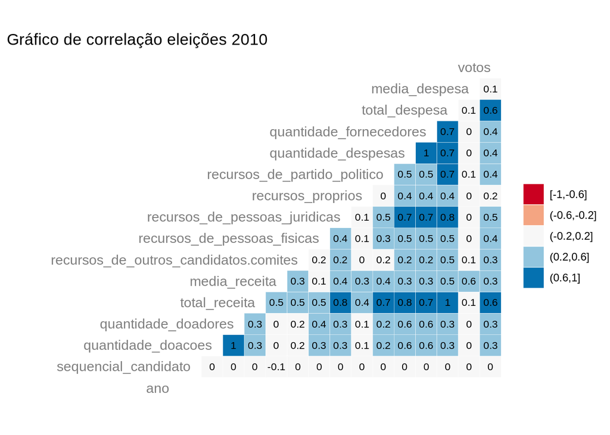

```r
dados_2010 %>%
  na.omit() %>%
  ggcorr(palette = "RdBu",
         color = "grey50",
         label = TRUE, hjust = 1,
         label_size = 3, size = 4,
         nbreaks = 5, layout.exp = 7) +
  ggtitle("Gráfico de correlação eleições 2010")
```

### 4- No caso de haver variáveis pouco explicativas e/ou redudantes, construa um novo modelo sem essas variáveis e o compare ao modelo com todas as variáveis (e.g. em termos de R2 e RSE). Faça isso para 2006 e 2010 separadamente.

```r
dados_filtrados_2006 <- dados_2006 %>%
  select(-partido,
         -uf,-nome,
         -estado_civil,
         -ocupacao,-ano,
         -cargo,-grau,-sexo)


lmModel2006 <- dados_filtrados_2006 %>%
  lm(formula = votos ~ .
     -recursos_de_pessoas_fisicas
     -recursos_de_pessoas_juridicas
     -quantidade_fornecedores
     -quantidade_doacoes
     -total_receita)

summary(lmModel2006)
```

```
##
## Call:
## lm(formula = votos ~ . - recursos_de_pessoas_fisicas - recursos_de_pessoas_juridicas -
##     quantidade_fornecedores - quantidade_doacoes - total_receita,
##     data = .)
##
## Residuals:
##     Min      1Q  Median      3Q     Max
## -236808   -7413   -4737    -901  634797
##
## Coefficients:
##                                         Estimate Std. Error t value
## (Intercept)                            1.558e+04  7.992e+03   1.949
## sequencial_candidato                  -1.073e+00  7.358e-01  -1.458
## quantidade_doadores                    2.967e+02  1.698e+01  17.471
## media_receita                          1.180e+00  1.030e-01  11.450
## recursos_de_outros_candidatos.comites -4.613e-02  1.705e-02  -2.706
## recursos_proprios                     -7.255e-02  7.438e-03  -9.753
## recursos_de_partido_politico          -7.853e-02  1.825e-02  -4.303
## quantidade_despesas                   -2.394e+01  3.256e+00  -7.352
## total_despesa                          1.088e-01  5.085e-03  21.400
## media_despesa                          1.033e+00  4.188e-01   2.467
##                                       Pr(>|t|)
## (Intercept)                            0.05132 .
## sequencial_candidato                   0.14487
## quantidade_doadores                    < 2e-16 ***
## media_receita                          < 2e-16 ***
## recursos_de_outros_candidatos.comites  0.00685 **
## recursos_proprios                      < 2e-16 ***
## recursos_de_partido_politico          1.73e-05 ***
## quantidade_despesas                   2.43e-13 ***
## total_despesa                          < 2e-16 ***
## media_despesa                          0.01366 *
## ---
## Signif. codes:  0 '***' 0.001 '**' 0.01 '*' 0.05 '.' 0.1 ' ' 1
##
## Residual standard error: 31830 on 3426 degrees of freedom
## Multiple R-squared:  0.5113, Adjusted R-squared:   0.51
## F-statistic: 398.2 on 9 and 3426 DF,  p-value: < 2.2e-16
```

```r
broom::glance(lmModel2006)
```

```
## # A tibble: 1 x 11
##   r.squared adj.r.squared  sigma statistic p.value    df  logLik    AIC
## *     <dbl>         <dbl>  <dbl>     <dbl>   <dbl> <int>   <dbl>  <dbl>
## 1     0.511         0.510 31833.      398.       0    10 -40496. 81014.
## # ... with 3 more variables: BIC <dbl>, deviance <dbl>, df.residual <int>
```

```r
dados_filtrados_2010 <- dados_2010 %>%
  select(-partido,
         -uf,-nome,
         -estado_civil,
         -ocupacao,-ano,
         -cargo,-grau,-sexo)


lmModel2010 <- dados_filtrados_2010 %>%
  lm(formula = votos ~ .
     -recursos_de_pessoas_fisicas
     -recursos_de_pessoas_juridicas
     -quantidade_fornecedores
     -quantidade_doacoes
     -total_receita)

summary(lmModel2010)
```

```
##
## Call:
## lm(formula = votos ~ . - recursos_de_pessoas_fisicas - recursos_de_pessoas_juridicas -
##     quantidade_fornecedores - quantidade_doacoes - total_receita,
##     data = .)
##
## Residuals:
##     Min      1Q  Median      3Q     Max
## -231009   -8951   -6814   -2871 1305003
##
## Coefficients:
##                                         Estimate Std. Error t value
## (Intercept)                            1.307e+04  1.607e+03   8.131
## sequencial_candidato                  -2.505e-08  8.527e-09  -2.938
## quantidade_doadores                    2.332e+01  5.511e+00   4.231
## media_receita                         -2.198e-01  5.396e-02  -4.074
## recursos_de_outros_candidatos.comites  4.766e-03  5.406e-03   0.882
## recursos_proprios                     -3.289e-02  4.097e-03  -8.028
## recursos_de_partido_politico          -3.378e-03  5.221e-03  -0.647
## quantidade_despesas                   -1.110e+01  2.097e+00  -5.295
## total_despesa                          8.125e-02  2.912e-03  27.906
## media_despesa                          1.826e-01  9.002e-02   2.028
##                                       Pr(>|t|)
## (Intercept)                           5.59e-16 ***
## sequencial_candidato                   0.00332 **
## quantidade_doadores                   2.38e-05 ***
## media_receita                         4.72e-05 ***
## recursos_de_outros_candidatos.comites  0.37808
## recursos_proprios                     1.29e-15 ***
## recursos_de_partido_politico           0.51772
## quantidade_despesas                   1.25e-07 ***
## total_despesa                          < 2e-16 ***
## media_despesa                          0.04262 *
## ---
## Signif. codes:  0 '***' 0.001 '**' 0.01 '*' 0.05 '.' 0.1 ' ' 1
##
## Residual standard error: 37430 on 4030 degrees of freedom
## Multiple R-squared:  0.4309, Adjusted R-squared:  0.4296
## F-statistic:   339 on 9 and 4030 DF,  p-value: < 2.2e-16
```

```r
broom::glance(lmModel2010)
```

```
## # A tibble: 1 x 11
##   r.squared adj.r.squared  sigma statistic p.value    df  logLik    AIC
## *     <dbl>         <dbl>  <dbl>     <dbl>   <dbl> <int>   <dbl>  <dbl>
## 1     0.431         0.430 37428.      339.       0    10 -48269. 96561.
## # ... with 3 more variables: BIC <dbl>, deviance <dbl>, df.residual <int>
```

### 5- Construa agora uma regressão considerando os anos 2006 e 2010 em conjunto. Que diferenças/semelhanças você percebe em relação aos modelos individuais por ano? Veja a questão 2 para sugestões que você usar para comparação.

```r
dados_filtrados_2006_2010 <- dados_2006_2010 %>%
  select(-partido,
         -uf,-nome,
         -estado_civil,
         -ocupacao,-ano,
         -cargo,-grau,-sexo)


lmModel2006_2010 <- dados_filtrados_2006_2010 %>%
  lm(formula = votos ~ .
     -recursos_de_pessoas_fisicas
     -recursos_de_pessoas_juridicas
     -quantidade_fornecedores
     -quantidade_doacoes
     -total_receita)

summary(lmModel2006_2010)
```

```
##
## Call:
## lm(formula = votos ~ . - recursos_de_pessoas_fisicas - recursos_de_pessoas_juridicas -
##     quantidade_fornecedores - quantidade_doacoes - total_receita,
##     data = .)
##
## Residuals:
##     Min      1Q  Median      3Q     Max
## -345818  -12051   -6579   -1395 1317628
##
## Coefficients:
##                                         Estimate Std. Error t value
## (Intercept)                            1.339e+04  6.112e+02  21.906
## sequencial_candidato                  -3.917e-08  4.324e-09  -9.059
## quantidade_doadores                    4.350e+01  5.093e+00   8.542
## media_receita                          1.013e-01  4.706e-02   2.153
## recursos_de_outros_candidatos.comites -2.693e-02  4.926e-03  -5.467
## recursos_proprios                     -5.213e-02  3.573e-03 -14.591
## recursos_de_partido_politico          -4.603e-02  4.583e-03 -10.044
## quantidade_despesas                   -1.515e+01  1.770e+00  -8.562
## total_despesa                          1.028e-01  2.464e-03  41.724
## media_despesa                         -1.706e-02  8.474e-02  -0.201
##                                       Pr(>|t|)
## (Intercept)                            < 2e-16 ***
## sequencial_candidato                   < 2e-16 ***
## quantidade_doadores                    < 2e-16 ***
## media_receita                           0.0314 *
## recursos_de_outros_candidatos.comites 4.73e-08 ***
## recursos_proprios                      < 2e-16 ***
## recursos_de_partido_politico           < 2e-16 ***
## quantidade_despesas                    < 2e-16 ***
## total_despesa                          < 2e-16 ***
## media_despesa                           0.8405
## ---
## Signif. codes:  0 '***' 0.001 '**' 0.01 '*' 0.05 '.' 0.1 ' ' 1
##
## Residual standard error: 36620 on 7466 degrees of freedom
## Multiple R-squared:  0.4118, Adjusted R-squared:  0.4111
## F-statistic: 580.7 on 9 and 7466 DF,  p-value: < 2.2e-16
```

```r
broom::glance(lmModel2006_2010)
```

```
## # A tibble: 1 x 11
##   r.squared adj.r.squared  sigma statistic p.value    df  logLik    AIC
## *     <dbl>         <dbl>  <dbl>     <dbl>   <dbl> <int>   <dbl>  <dbl>
## 1     0.412         0.411 36624.      581.       0    10 -89164. 1.78e5
## # ... with 3 more variables: BIC <dbl>, deviance <dbl>, df.residual <int>
```

Em relação aos modelos indivídais, o R² e O RSE são bem próximos, o que indica que o modelo se ajusta forma semelhante em ambos os casos (juntos ou separados).

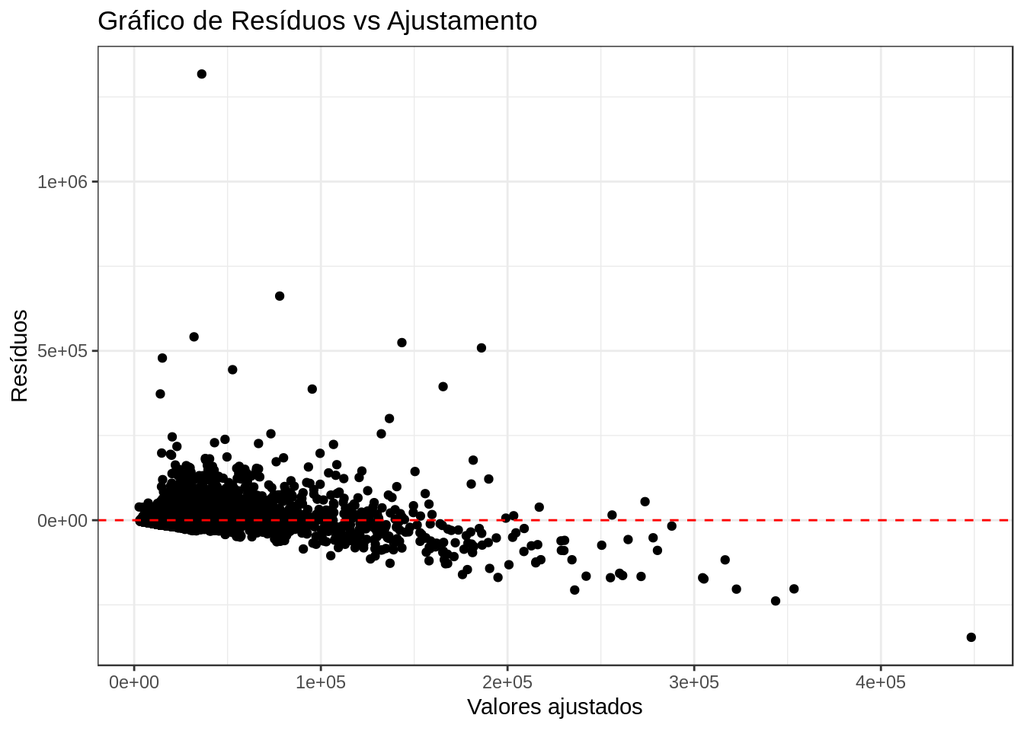

```r
p1 = ggplot(lmModel2006_2010, aes(.fitted, .resid)) +
    geom_point()
p1 = p1 + geom_hline(yintercept=0, col="red", linetype="dashed")
p1 = p1 + xlab("Valores ajustados") + ylab("Resíduos")
p1 = p1 + ggtitle("Gráfico de Resíduos vs Ajustamento") +
    theme_bw()
p1
```

O padrão observado no plot de resíduos dos dados individualemente se manteve no plot dos dados juntos, mostrando que mais dados não foram suficientes para melhorar o modelo.

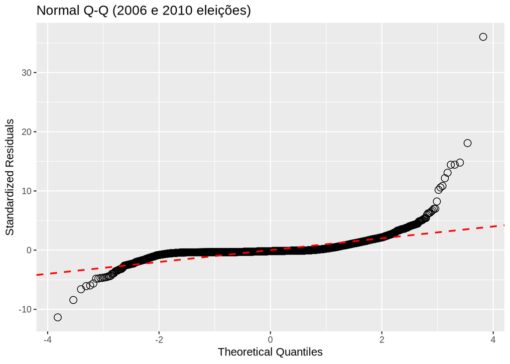

```r
lmModel2006_2010 %>%
  ggplot(aes(sample=rstandard(.))) +
  stat_qq(na.rm = TRUE,
          shape=1,size=3) +
  labs(title="Normal Q-Q (2006 e 2010 eleições)",        # plot title
  x="Theoretical Quantiles",      # x-axis label
  y="Standardized Residuals") +   # y-axis label +
  geom_abline(color = "red",
              size = 0.8,
              linetype="dashed")  # dashed reference line
```

Pode-se observar que no gráfico acima, a distribuição dos erros são semelhantes aos dos gráficos dos dados individuais.

Comparando de forma geral os modelos com os dados individuais dos anos e o modelo com os dados juntos, é possível perceber que mesmo com a adição de mais dados (Juntando os dois conjuntos) o modelo gerado permaneceu semelhante aos individuais, o que mostra que somente a adição de mais dados não é suficiente para melhorar o modelo, é preciso também melhorar a função que é aplicada nos dados, diminuindo o erro de predição. Além disso é preciso tomar cuidado com a superespecialização do modelo (overfitting), que faz com que ele seja muito bom para o conjunto de dados já coletado, mas que não é bom para dados nunca vistos.